# Modeling ChIP-Seq data with GenoGAM2: A Genome-wide generalized additive model

Georg Stricker and Julien Gagneur

Technical University Munich

georg.stricker@gmx.net  
gagneur@in.tum.de

03/27/2018

#### Abstract

Many genomic assays lead to noisy observations of a biological quantity of interest varying along the genome. This is the case for ChIP-Seq, for which read counts reflect local protein occupancy of the ChIP-ed protein. The fastGenoGAM package allows statistical analysis of genome-wide data with smooth functions using generalized additive models. This vignette explains the use of the package for typical ChIP-Seq analysis workflow.

#### Package

fastGenoGAM 1.99

**Note:** if you use fastGenoGAM in published research, please cite:

> Stricker and Engelhardt, et al. (2017) GenoGAM: Genome-wide generalized additive models for ChIP-seq analysis *Bioinformatics*, **33**:15. 10.1093/bioinformatics/btx150

# 1 Quick guide (with HDF5)

This is the brief version of the usual workflow of fastGenoGAM. It involves:

- Reading in data through `GenoGAMDataSet()` to get a `GenoGAMDataSet` object. This is done with the HDF5 backend.
- Computing size factors with `computeSizeFactors()`
- Compute the model with `genogam()` to get the result `GenoGAM` object
- compute position-wise log p-values with `computeSignificance()`

## 1.1 Getting started

The example dataset is restricted to the first 100kb of the first yeast chromosome.

1. We set some required meta variables

```r
library(fastGenoGAM)

## A.
## specify folder and experiment design path
wd <- system.file("extdata/Set1", package='fastGenoGAM')
folder <- file.path(wd, "bam")
expDesign <- file.path(wd, "experimentDesign.txt")

## B.
## set HDF5 folder where the data will be stored
## Note, don't usually use /tmp because all your data and
## results get deleted otherwise later
hdf5_folder <- tempdir()
settings <- GenoGAMSettings(hdf5Control = list(dir = hdf5_folder))

## C.
## register parallel backend (default is "the number of cores" - 2)
## Here we also use the SnowParam backend which is advised for larger data
## For yeast MulticoreParam should also do fine
BiocParallel::register(BiocParallel::SnowParam(worker = 2))

## D.
## specify chunk and overhang size. It is possible to skip this,
## but the automatic specification would prevent us from using
## multiple tiles in such a small example.
chunkSize <- 50000
overhangSize <- 1000

## E.
## the experiment design reflecting the underlying GAM
## x = position
design <- ~ s(x) + s(x, by = genotype)
```

2. Read in the data to obtain a `Robject{"GenoGAMDataSet"}` object. Warnings about out-of-bound ranges can be ignored, as they occur during the shifting process when the genome gets tiled. It is trimmed accordingly. I have not yet figured out how to silent those warnings. The usual `suppressWarnings` does not seem to work in the parallel Snow environment.

```r
## build the GenoGAMDataSet with HDF5 backend
ggd <- GenoGAMDataSet(
  expDesign, directory = folder,
  chunkSize = chunkSize, overhangSize = overhangSize,
  design = design,
  settings = settings, hdf5 = TRUE
)
```

```
## INFO [2018-03-27 19:26:26] Creating GenoGAMDataSet
## INFO [2018-03-27 19:26:29] Reading in data
## INFO [2018-03-27 19:26:29] Reading in wt_1
## INFO [2018-03-27 19:26:31] Reading in wt_2
## INFO [2018-03-27 19:26:31] Reading in mutant_1
## INFO [2018-03-27 19:26:32] Reading in mutant_2
## INFO [2018-03-27 19:26:32] Finished reading in data
## INFO [2018-03-27 19:26:33] Writing chrI to HDF5
## INFO [2018-03-27 19:26:33] chrI written
## INFO [2018-03-27 19:26:34] GenoGAMDataSet created
```

```r
ggd
```

```
## class: GenoGAMDataSetList
## dimension: 1e+05 4
## samples(4): wt_1 wt_2 mutant_1 mutant_2
## design variables(1): genotype
## tiles size: 52kbp
## number of tiles: 2
## chromosomes: chrI
## size factors:
##     wt_1     wt_2 mutant_1 mutant_2
##        0        0        0        0
## formula:
## ~ s(x) + s(x, by = genotype)
```

3. Compute Size factors

```r
## compute size factors
ggd <- computeSizeFactors(ggd)
```

```
## INFO [2018-03-27 19:26:34] Computing size factors
## INFO [2018-03-27 19:26:36] DONE
```

```r
ggd
```

```
## class: GenoGAMDataSetList
## dimension: 1e+05 4
## samples(4): wt_1 wt_2 mutant_1 mutant_2
## design variables(1): genotype
## tiles size: 52kbp
## number of tiles: 2
## chromosomes: chrI
## size factors:
##        wt_1        wt_2    mutant_1    mutant_2
## -0.04156987  0.04210819 -0.25589212  0.14328182
## formula:
## ~ s(x) + s(x, by = genotype)
```

```r
## the data
assay(ggd)
```

```
## $chrI
## <100000 x 4> DelayedMatrix object of type "integer":
##           wt_1 wt_2 mutant_1 mutant_2
##      [1,]    0    0        0        0
##      [2,]    0    0        0        0
##      [3,]    0    0        0        0
##      [4,]    0    0        0        0
##      [5,]    0    0        0        0
##       ...    .    .        .        .
##  [99996,]    0    0        0        0
##  [99997,]    0    0        0        0
##  [99998,]    0    0        0        0
##  [99999,]    0    0        0        0
## [100000,]    1    1        0        0
```

## 1.2 Fitting the model

1. Compute model with fixed hyperparameters

```r
## compute model without parameter estimation to save time in vignette
result <- genogam(ggd, lambda = 4601, theta = 4.51)
```

```
## INFO [2018-03-27 19:26:37] Initializing the model
## INFO [2018-03-27 19:26:37] Done
## INFO [2018-03-27 19:26:37] Fitting model
## INFO [2018-03-27 19:26:37] Fitting chrI
## INFO [2018-03-27 19:26:57] chrI Done
## INFO [2018-03-27 19:26:57] Processing Fits
## INFO [2018-03-27 19:26:57] Processing done
## INFO [2018-03-27 19:26:57] Finished
```

```r
result
```

```
## Family:  nb
## Formula:  ~ s(x) + s(x, by = genotype)
## Class: GenoGAMList
## Dimension: 1e+05 2
## Samples(4): wt_1 wt_2 mutant_1 mutant_2
## Design variables(1): genotype
## Smooth functions(2): s(x) s(x):genotype
## Chromosomes: chrI
##
## Size factors:
##        wt_1        wt_2    mutant_1    mutant_2
## -0.04156987  0.04210819 -0.25589212  0.14328182
##
## Cross Validation:  Not performed
##
## Spline Parameters:
##   Knot spacing:  20
##   B-spline order:  2
##   Penalization order:  2
##
## Tile settings:
##   Chunk size: 50000
##   Tile size: 52000
##   Overhang size: 1000
##   Number of tiles: 2
##   Evaluated genome ranges:
## GRanges object with 1 range and 0 metadata columns:
##       seqnames    ranges strand
##          <Rle> <IRanges>  <Rle>
##   [1]     chrI  1-100000      *
##   -------
##   seqinfo: 1 sequence from an unspecified genome
```

```r
## the fit and standard error
fits(result)
```

```
## $chrI
## <100000 x 2> DelayedMatrix object of type "double":
##                 s(x) s(x):genotype
##      [1,] -2.8119023     0.5320456
##      [2,] -2.8112872     0.5318488
##      [3,] -2.8106723     0.5316519
##      [4,] -2.8100574     0.5314549
##      [5,] -2.8094428     0.5312576
##       ...          .             .
##  [99996,] -1.8677219    -0.1100048
##  [99997,] -1.8752766    -0.1103506
##  [99998,] -1.8828313    -0.1106965
##  [99999,] -1.8903860    -0.1110424
## [100000,] -1.8979408    -0.1113884
```

```r
se(result)
```

```
## $chrI
## <100000 x 2> DelayedMatrix object of type "double":
##                s(x) s(x):genotype
##      [1,] 0.2586475     0.3176420
##      [2,] 0.2575216     0.3164051
##      [3,] 0.2564013     0.3151735
##      [4,] 0.2552866     0.3139473
##      [5,] 0.2541776     0.3127265
##       ...         .             .
##  [99996,] 0.1569068     0.2093811
##  [99997,] 0.1579245     0.2105446
##  [99998,] 0.1589481     0.2117133
##  [99999,] 0.1599775     0.2128871
## [100000,] 0.1610127     0.2140660
```

2. Compute log p-values

```r
computeSignificance(result)
```

```
## INFO [2018-03-27 19:26:58] Computing positionwise log p-values
## INFO [2018-03-27 19:26:59] DONE
```

```r
pval(result)
```

```
## $chrI
## <100000 x 2> DelayedMatrix object of type "double":
##                 s(x) s(x):genotype
##      [1,]  0.4996795     4.0098114
##      [2,]  0.4989391     4.0217199
##      [3,]  0.4982052     4.0336833
##      [4,]  0.4974786     4.0456991
##      [5,]  0.4967588     4.0577679
##       ...          .             .
##  [99996,] 27.6024513     0.1714507
##  [99997,] 26.8324223     0.1734573
##  [99998,] 26.0822506     0.1754717
##  [99999,] 25.3515072     0.1774937
## [100000,] 24.6397362     0.1795230
```

Plot results of the center 10kb, where both tiles are joined together. A proper plotting functions is in development.

```r
idx <- 45000:55000
upper_input <- fits(result)$chrI[,"s(x)"][idx] + 2*se(result)$chrI[,"s(x)"][idx]
lower_input <- fits(result)$chrI[,"s(x)"][idx] - 2*se(result)$chrI[,"s(x)"][idx]

upper_ip <- fits(result)$chrI[,"s(x):genotype"][idx] + 2*se(result)$chrI[,"s(x):genotype"][idx]
lower_ip <- fits(result)$chrI[,"s(x):genotype"][idx] - 2*se(result)$chrI[,"s(x):genotype"][idx]
```

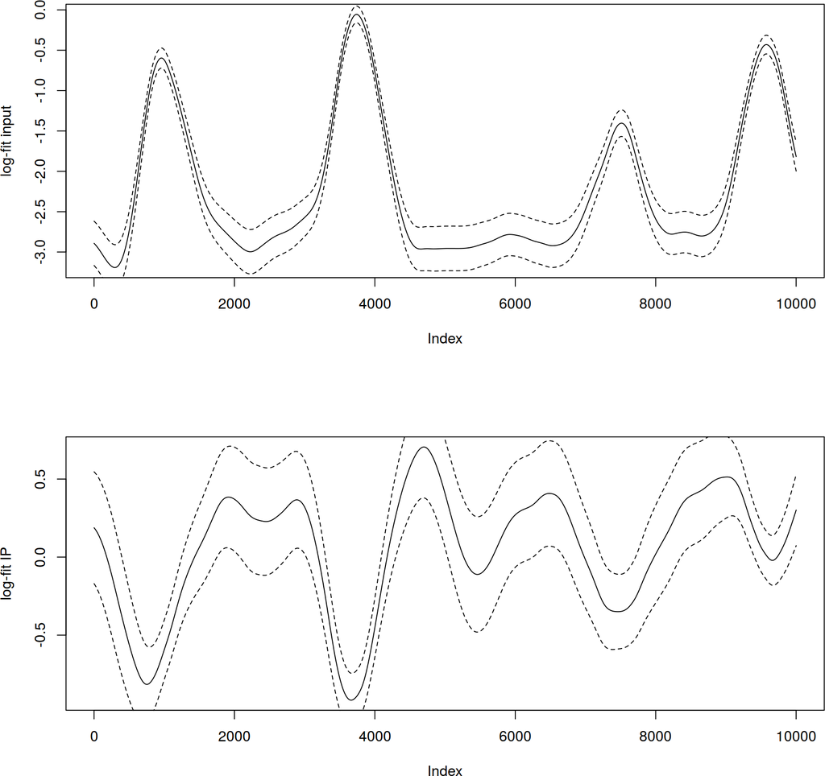

Figure 1: The fit of input (upper) and IP (lower) for chrI:45000-55000

```r
par(mfrow = c(2,1))
plot(fits(result)$chrI[,"s(x)"][idx], type = "l", ylab = "log-fit input")
lines(upper_input, lty = 2)
lines(lower_input, lty = 2)

plot(fits(result)$chrI[,"s(x):genotype"][idx], type = "l", ylab = "log-fit IP")
lines(upper_ip, lty = 2)
lines(lower_ip, lty = 2)
```

# 2 FAQ

## 2.1 Armadillo Error

**Problem:** An error occurs during model fitting along those lines:

`error: matrix multiplication: incompatible matrix dimensions: 22333830147200x5360120267008000 and 4294972496x1`

**Solution:** First, make sure you have all Armadillo dependencies installed correctly. See [here](http://arma.sourceforge.net/download.html)

Second, the error is most likely related to the fact, that Armadillo is using 32bit matrices, thus causing problems for large matrices fastGenoGAM is using. The solution is to enable `ARMA_64BIT_WORD`, which is not enabled in RcppArmadillo by default. This should have been done during compilation, but if it fails for some reason you can do it manually with `#define ARMA_64BIT_WORD 1` in `my_R_Directory/lib/R/library/RcppArmadillo/include/RcppArmadilloConfig.h`. See [here](https://stackoverflow.com/questions/40592054/large-matrices-in-rcpparmadillo-via-the-arma-64bit-word-define).

# 3 Acknowledgments

We thank Alexander Engelhardt, Mathilde Galinier, Simon Wood, Herv'e Pag`es, and Martin Morgan for input in the development of fastGenoGAM

```
## R Under development (unstable) (2017-12-28 r73968)
## Platform: x86_64-pc-linux-gnu (64-bit)
## Running under: Linux Mint LMDE
##
## Matrix products: default
## BLAS: /home/juri/R-devel-Bioc/lib/R/lib/libRblas.so
## LAPACK: /home/juri/R-devel-Bioc/lib/R/lib/libRlapack.so
##
## locale:
##  [1] LC_CTYPE=en_US.UTF-8       LC_NUMERIC=C
##  [3] LC_TIME=en_US.UTF-8        LC_COLLATE=en_US.UTF-8
##  [5] LC_MONETARY=en_US.UTF-8    LC_MESSAGES=en_US.UTF-8
##  [7] LC_PAPER=en_US.UTF-8       LC_NAME=C
##  [9] LC_ADDRESS=C               LC_TELEPHONE=C
## [11] LC_MEASUREMENT=en_US.UTF-8 LC_IDENTIFICATION=C
```

[output cut: 57 more lines]

# 5 References